# match

Maita Schade

Aug 26, 2019

Given a target sample, recoded panel, and possibly previous invites and completes, this notebook produces a new set of panelists to invite, with flexible number of columns (for larger batches).

Make sure we’re dealing with a clear space:

```r
rm(list = ls(all = TRUE))
```

Set the space up. Country is the only thing you should need to set manually, if the files are all set up properly.

```r
country <- "AR"
```

Defining files–make sure the dirs are okay; other than that you shouldn’t need to touch this if the file structure is set up properly.

```r
#strats = ("GEO1_AR2010")
#strat2 = "URBAN"
# wave = 17
# filedate = "190826"

datadir <- paste0('C:/Users/schadem/Box Sync/LAPOP Shared/working documents/maita/Coordination/IDB Online Crime/Matching process/Data/',country,'/')



panelfile <- paste0(rawdir,'panel/', country, '_netquest_recoded.csv')

recodepath <- paste0("./recode_Netquest_IPUMS_",country, ".csv") #table specifying recodes
parampath <- "./country_parameters.csv" # set specefic parameters in this file

responsefile <- paste0('C:/Users/schadem/Box Sync/LAPOP Shared/working documents/maita/Coordination/IDB Online Crime/Data processing/Data/IADB+Argentina+Questionnaire+-+Netquest+v2_October+28%2C+2019_08.59.csv')
#file of not yet sent IDs
# excludefile <- paste0('C:/Users/schadem/Box Sync/LAPOP Shared/working documents/maita/Coordination/Noam Argentina Panel/Data processing/Data/APE_2019_sept7v2_October 7, 2019_09.01.csv')
#recyclefile <- paste0(datadir, "panel/AR_selected_wave1_QC.csv")
```

```r
library('MatchIt')
library('data.table')
library('openxlsx')
# library('labelled')
#
# require(plyr)
# require(reshape2)
library(stringr)
```

Load country-specific parameters:

```r
params <- fread(parampath,key = "country")[country,]
target.date <- params[,target.date]
print(paste0("Target date is ", target.date))
```

```
[1] "Target date is 191010"
```

```r
NQ_id <- params[,NQ_id]

# On repeated sampling, just make sure that the previous target is re-used
targetfile <- paste0(datadir, "sample/", country, "_target_", target.date, ".csv")
```

Load data

```r
target <- fread(targetfile)
target <- fread(targetfile, colClasses = c(sampleId="character"))
target[,sampleId:=str_pad(sampleId,width=13,pad="0")]
panel <- fread(panelfile)
if(exists("recyclefile")){
  recycle <- fread(recyclefile)
}
length(unique(panel$X))
```

```
[1] 335
```

```r
length(unique(target$X))
```

```
[1] 261
```

```r
set.seed(250291)
target.pre <- target[sample(.N,600)]
head(target.pre)
```

| sampleId | gend | age | bath | ed | emp | pern | hhh | X | Y |
| --- | --- | --- | --- | --- | --- | --- | --- | --- | --- |
| 0377409000011 | 2 | 86 | 1 | 2 | 1 | 1 | 1 | -58.01810 | -35.00340 |
| 0333487000041 | 1 | 29 | 1 | 3 | 1 | 6 | 2 | -58.62461 | -34.76931 |
| 0548334000031 | 1 | 51 | 1 | 2 | 1 | 4 | 2 | -59.18234 | -37.33642 |
| 0339642000021 | 1 | 20 | 1 | 2 | 1 | 5 | 2 | -58.62461 | -34.76931 |
| 1168448000021 | 1 | 30 | 1 | 5 | 1 | 2 | 2 | -63.54311 | -27.47258 |
| 1200439000011 | 1 | 79 | 1 | 5 | 3 | 3 | 1 | -65.21785 | -26.83331 |

If using the pre-election sample, load it from the first wave…

[output not shown]

[output cut: 590 more lines]

Are there exclusions from a prior survey? If so, remove them from the panel.

```r
dim(panel)
```

```
[1] 232633     10
```

```r
if (exists("excludefile")){
  print(paste0("excluding previous respondents from ",excludefile))

  #The following will depend on the file that we're reading exclusions from
  exclude <- fread(excludefile)
  exclude[,"panelId" := substr(ticket,1,16)]

  # Prune panel to exclude previous respondents
  panel <- panel[!panelId %in% exclude$panelId,]

}
dim(panel)
```

```
[1] 232633     10
```

Are there previous invites? If so, load them. Also, prune the panel to just those not previously invited.

```r
if (length(list.files(path=paste0(datadir,"panel/"), pattern = "wave"))>0){
  print("previous invites found")
  # Printing what invites are considered
  cat(paste0("Included invite files: \n"))

  # Reading in invite files from all waves
  waves <- lapply(
    grep("QC",list.files(path=paste0(datadir,"panel/"), pattern = "wave"),
         invert = T, value = T),
    function (x){
      cat(paste0("    ",x,"\n"))
    ## We make sure the individual waves have distinguishable names by attaching suffixes

      df<-fread(paste0(datadir, "panel/",x),colClasses = c(sampleId="character"))
      df[,sampleId := str_pad(string = sampleId, width = max(nchar(sampleId)), side = "left", pad = "0")]
      #df[,grep("panelId",names(df),value = T)]<-sapply(df[,grep("panelId",names(df),value = T)], tolower)
      nwave=as.numeric(str_match(x, "wave(\\d+)")[2])
      suffix=paste0(".",((nwave-1)*5)+1:(ncol(df)-1))
      # print(suffix)
      names(df)[grep("panelId.?",names(df))] <- paste0("panelId",suffix)
      return(df)

   }
  )

  # The target is a table of target records, with selected panelist IDs for each wave
  target.select <- Reduce(function(dtf1, dtf2) {merge(dtf1, dtf2,
                                               by = c("sampleId"),
                                               all.x = TRUE)},
                   waves)

  # target <- target[names(target)[,-grep("targetId|X",names(target))]]

  # "selected" is a long list of all NQ panelists selected from our end
  selected.wide <- Reduce(function(dtf1, dtf2) {merge(dtf1, dtf2,
                                               by = c("sampleId"),
                                               all.x = TRUE, all.y = TRUE)},
                   waves)
  selected.wide
  # selected <- selected_wide[names(selected_wide)[-grep("targetId|X",names(selected_wide))]]
  selected <- melt(data = selected.wide,measure.vars = c(grep("panelId",names(selected.wide))))

  names(selected)<-c("sampleId",   "variable",   "panelId")
  selected[,batch:= as.integer(str_match(variable,"\\d\\d?"))]

  selected<-selected[selected[,!is.na(panelId)],]
  # selected$wave <- as.integer(regmatches(selected$variable,
  #                                        regexpr("\\.\\K\\d+$",selected$variable,perl=TRUE)
  #                                        )
  #                             )


  # what is going on with more removals than recycled IDs?
  # I would expect that the number of recycles minus the number of duplicates equals the removals.
  if(exists("recycle")){
    # Remove who was _not_ invited
    names(recycle)[1] <- "panelId"
    actually.used <- (!(selected$panelId%in%recycle$panelId))|(selected$batch>5)
    nrow(selected)-sum(actually.used)


    invited <- selected[actually.used,]
    dim(invited)
  } else {
    invited <- selected
  }
  # Prune panel to exclude invited
  panel <- panel[!panelId %in% invited$panelId,]

  # set wave
  wave <- length(waves)+1

  #Check that target.select and target are compatible (and nothing got somehow messed up when fixing to dept)
  #Are we okay--did we not mess up the sample when fixing depts?
  if(sum(!target.select$sampleId%in%target$sampleId)==0){ #if all IDs in selected are in sample
    #target <- target[sampleId%in%target.select$sampleId]
  }


} else {wave <- 1}
print(wave)
```

```
[1] "previous invites found"
Included invite files:
    AR_selected_wave1_191010.csv
    AR_selected_wave2_191016.csv
    AR_selected_wave3_191023.csv
NULL
```

```r
wave
```

```
[1] 4
```

```r
nrow(target)
```

```
[1] 1200
```

```r
nrow(target.pruned)
```

```
[1] 654
```

Netquest wanted to know which targets were already complete, so find them and write them out.

```r
write.csv(target[!sampleId%in%target.pruned$sampleId,sampleId],
          paste0("completes_",format(Sys.time(),"%y%m%d"),".csv"))
```

Add a treatment into it:

```r
panel[,'treat':= rep(0,nrow(panel))]
target.pruned[,'treat':=rep(1,nrow(target.pruned))]
```

Now join this data together:

```r
alldata <- rbind(panel, target.pruned, fill=T)
#fill NA
alldata[is.na(panelId),panelId:="9999999999"]
alldata[is.na(sampleId),sampleId:="9999999999"]

head(alldata)
```

| gend | age | bath | ed | emp | pern | hhh | X | Y | panelId | treat | sampleId |
| --- | --- | --- | --- | --- | --- | --- | --- | --- | --- | --- | --- |
| 1 | 40 | 1 | 4 | 1 | 1 | 1 | -60.67004 | -36.85726 | 00005234bd11c7f7 | 0 | 9999999999 |
| 2 | 21 | 1 | 3 | 1 | 2 | 1 | -68.35056 | -34.94603 | 00005782b0268430 | 0 | 9999999999 |
| 1 | 37 | 1 | 4 | 1 | 2 | 1 | -64.49334 | -33.32973 | 000070f97c30847d | 0 | 9999999999 |
| 2 | 45 | 1 | 3 | 2 | 2 | 1 | -61.36077 | -30.23029 | 0000da21a0475471 | 0 | 9999999999 |
| 2 | 18 | 1 | 1 | 2 | 12 | 2 | -58.69143 | -34.55128 | 0000f966bc7d2343 | 0 | 9999999999 |
| 2 | 36 | 1 | 3 | 1 | 3 | 1 | -58.27678 | -34.73492 | 000141d93d58ab5a | 0 | 9999999999 |

Divide target sample into age quantiles (in this case, deciles) and add that to the data:

```r
age_q <- quantile(target$age,prob = seq(0,1,0.1)) #this is the full target
alldata[,'age_group' :=  as.integer(cut(alldata$age,breaks = age_q, include.lowest = TRUE))]
alldata[is.na(age_group),age]
```

```
 [1] 100 100  99  99 100  99 100 100 100 100  99  99 100 100 100 100
```

```r
alldata$age_group[is.na(alldata$age_group)] <- 10 #highest age-group can get lost; fill it in
```

Load in matching.vars from recodefile

```r
recode_map <- fread(recodepath)
matching.vars <- unique(recode_map$common_var)
```

Now carry out the matching.

```r
matching.form <- as.formula(paste0("treat ~ ", paste(matching.vars, collapse=' + ')))
```

We’ll have to repeat this process (at least for everything except PS). * start empty dataframe initialized with target IDs * make a copy of the data to alter * for each i in range: + run the matching + store the matched IDs + store some overall metrics about the match + reduce the panel data * return the match objects

```r
matchRatio <- function(data, metric, n, exact = c()){
  # A wrapper for the MatchIt framework to carry out arbitrary numbers of successive matches
  # data must have:
  #   * sampleId
  #   * panelId
  #   * treat
  require(MatchIt)

  # assign the dataframe to hold the matching results
  df <- data.frame(matrix(ncol=1, nrow=sum(data$treat==1)))
  names(df) <- c("sampleId")
  df$sampleId <- data$sampleId[data$treat==1]

  # assign the object to hold all the matching information
  matches <- vector("list",n)

  # make a copy of the passed-in data
  data.copy <- data.frame(data)

  # loop over the number of respondents per target
  # if there are issues, can I relax the age groups?
  for(i in 1:n){
    print(paste('i = ',as.character(i)))
    m <- matchit(matching.form,
                 data = data.copy, exact=exact, method = "nearest", distance = metric)
    controls <- match.data(m, group='control')

    try({matches[[i]] <- m
        sampleids <- data.copy[row.names(m$match.matrix), "sampleId"]
        panelids <- data.copy[m$match.matrix,"panelId"]
        ids <- data.frame(sampleId=sampleids, panelId=panelids, stringsAsFactors = F)
        df <- merge(x=df, y=ids, by="sampleId", all.x = TRUE, suffixes=c("",as.character(i)))
        }
    )
    data.copy <- data.copy[!data.copy$panelId %in% controls$panelId,] # not relying on rownames

  }
  return(list("ids"=df, "matches"=matches))
}
```

```r
n <- 5
matches = matchRatio(alldata, "mahalanobis", n, exact = c("age_group","gend"))
```

```
[1] "i =  1"
[1] "i =  2"
[1] "i =  3"
[1] "i =  4"
[1] "i =  5"
```

Save the id’s of the matches to a file

```r
write.csv(
  matches$ids,
  file=paste0(datadir,"panel/",country,"_selected_wave",wave,"_",format(Sys.time(),"%y%m%d"),".csv"),
  row.names = F)
wave
```

```
[1] 4
```

Make sure I got the right sampleIds…

```
[1] TRUE
```

Do I have a good number of discrete location codes?

```r
length(unique(panel$X))
```

```
[1] 335
```

```r
length(unique(target$X))
```

```
[1] 261
```

```r
sort(table(target$X))
```

[output not shown]

[output cut: 51 more lines]

```
                8                 8                 9                 9                 9
        -58.77705         -68.35056         -58.60644         -55.85806         -58.71143
                9                10                10                10                11
        -58.39412         -65.21785         -58.81036         -58.76402         -58.69143
               11                12                12                12                12
        -58.57883         -58.53794         -65.43261         -58.61929         -58.25806
               12                12                13                13                14
        -68.80085         -65.27118         -58.36688         -58.34136         -59.11455
               15                15                15                15                17
        -58.74125          -58.0181         -60.66962         -58.42347         -58.27678
               17                17                19                21                21
        -57.74006 -58.4488804101251         -60.70668         -64.18322         -58.62461
               22                23                28                38                62
        -58.44888
               77
```

What are these NAs? –oh, it was the censusId! fixed now.

What does the sample look like?

```r
set <- matches$ids
set <- Reduce(x = set[,grep("panelId",names(set),value = T)],f = append)
set <- panel[panelId%in%set,]

table(target.pruned$ed)/nrow(target.pruned)
```

```
         2          3          4          5          6
0.38532110 0.36085627 0.10091743 0.14067278 0.01223242
```

```r
table(set$ed)/nrow(set)
```

```
          1           2           3           4           5           6
0.004587156 0.319877676 0.414067278 0.117737003 0.131192661 0.012538226
```

```r
target.pruned[,censusId:=substr(sampleId,1,12)]
target.pruned[,PERNUM:=substr(censusId,11,12)]
target.pruned[,SERIAL:=substr(censusId,1,10)]
write.csv(target.pruned,paste0("pruned_target_",format(Sys.time(),"%y%m%d"),".csv"))
write.csv(set,paste0("selected_IDs_",format(Sys.time(),"%y%m%d"),".csv"))
```

What does it look like, compared to the old sample?

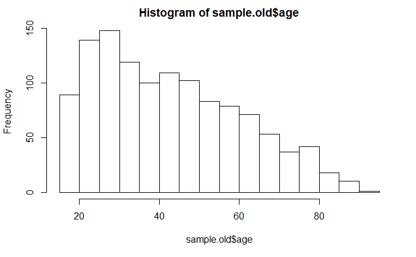

```r
sample.old <- fread("C:/Users/schadem/Box Sync/LAPOP Shared/working documents/maita/Coordination/Noam Argentina Panel/Matching process/Data/AR/sample/AR_target_20190909.csv")
hist(sample.old$age)
```

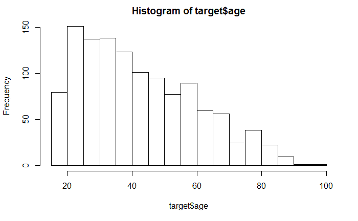

```r
hist(target$age)
```